# Classwork Assignment 10/17/2024

Last Updated: October 22, 2024 08:25:53

## MathEnrollment Data Questions

### a. What percent of the variability in spring enrollment is explained by the multipe linear regression model based off fall enrollment and academic year?

```r
summary(lm(Spring ~ Fall + AYear, data = math))
```

```
##
## Call:
## lm(formula = Spring ~ Fall + AYear, data = math)
##
## Residuals:
##     Min      1Q  Median      3Q     Max
## -30.613 -23.022   5.416   7.541  55.357
##
## Coefficients:
##               Estimate Std. Error t value Pr(>|t|)
## (Intercept) -8743.3901  6141.5341  -1.424    0.192
## Fall           -0.2021     0.3589  -0.563    0.589
## AYear           4.5159     3.0492   1.481    0.177
##
## Residual standard error: 31.09 on 8 degrees of freedom
## Multiple R-squared:  0.2773, Adjusted R-squared:  0.09663
## F-statistic: 1.535 on 2 and 8 DF,  p-value: 0.2728
```

`27.73%` of the variability in spring enrollment is explained by the multiple linear regression of fall enrollment and academic year.

### b. What is the size of the typical error for this multiple regression model?

```r
summary(lm(Spring ~ Fall + AYear, data = math))$sigma
```

```
## [1] 31.08974
```

The typical error for this multiple regression model is `31.08974`.

### c. Provide the ANOVA table for partitioning the total variability in spring enrollment based on this model and interpret the associated F-test.

```r
anova(lm(Spring ~ Fall + AYear, data = math))
```

```
## Analysis of Variance Table
##
## Response: Spring
##           Df Sum Sq Mean Sq F value Pr(>F)
## Fall       1  847.0  847.00  0.8763 0.3766
## AYear      1 2120.1 2120.06  2.1934 0.1769
## Residuals  8 7732.6  966.57
```

The F-value for the “Fall” variable is `0.8763`, and the corresponding p-value is `0.3766`. Since the p-value is greater than the common significance level (e.g., 0.05), we fail to reject the null hypothesis. This indicates that the “Fall” variable does not have a statistically significant effect on spring enrollment.

The F-value for the “AYear” variable is `2.1934`, with a p-value of `0.1769`. Again, since the p-value is greater than S.05, we fail to reject the null hypothesis, suggesting that “AYear” does not have a statistically significant effect on spring enrollment.

Based on the F-test results, neither “Fall” nor “AYear” significantly affects spring enrollment in this dataset, as indicated by the high p-values for both variables.

### d. Are the regression coefficients for both explanatory variables significantly different from zero? Provide appropriate hypotheses, test statistics, and P-values in order to make your conclusion.

```r
summary(lm(Spring ~ Fall + AYear, data = math))
```

```
##
## Call:
## lm(formula = Spring ~ Fall + AYear, data = math)
##
## Residuals:
##     Min      1Q  Median      3Q     Max
## -30.613 -23.022   5.416   7.541  55.357
##
## Coefficients:
##               Estimate Std. Error t value Pr(>|t|)
## (Intercept) -8743.3901  6141.5341  -1.424    0.192
## Fall           -0.2021     0.3589  -0.563    0.589
## AYear           4.5159     3.0492   1.481    0.177
##
## Residual standard error: 31.09 on 8 degrees of freedom
## Multiple R-squared:  0.2773, Adjusted R-squared:  0.09663
## F-statistic: 1.535 on 2 and 8 DF,  p-value: 0.2728
```

Ho: The regression coefficient for “Fall” is zero. Ha: The regression coefficient for “Fall” is not zero.

Fall: The estimated coefficient is -0.2021, with a standard error of 0.3589. The t-value is -0.563, and the p-value is 0.589. AYear: The estimated coefficient is 4.5159, with a standard error of 3.0492. The t-value is 1.481, and the p-value is 0.177.

The decision rule is to reject the null hypothesis if the p-value is less than the significance level (commonly 0.05).

- For Fall, the p-value is 0.589, which is much greater than 0.05. Therefore, we fail to reject the null hypothesis. This suggests that the coefficient for “Fall” is not significantly different from zero.
- For AYear, the p-value is 0.177, which is also greater than 0.05. So, we also fail to reject the null hypothesis for “AYear,” indicating that its coefficient is not significantly different from zero.

Based on the results, neither the “Fall” nor the “AYear” coefficients are significantly different from zero at the 0.05 significance level. This implies that neither variable has a statistically significant effect on the spring enrollment in this model.

## BrainpH Data Questions

### a. Make a scatterplot of `Y = pH` versus `X = Age and with Sex as a grouping variable (i.e., use different colors or different plotting symbols for the two levels of Sex). Comment on the plot.

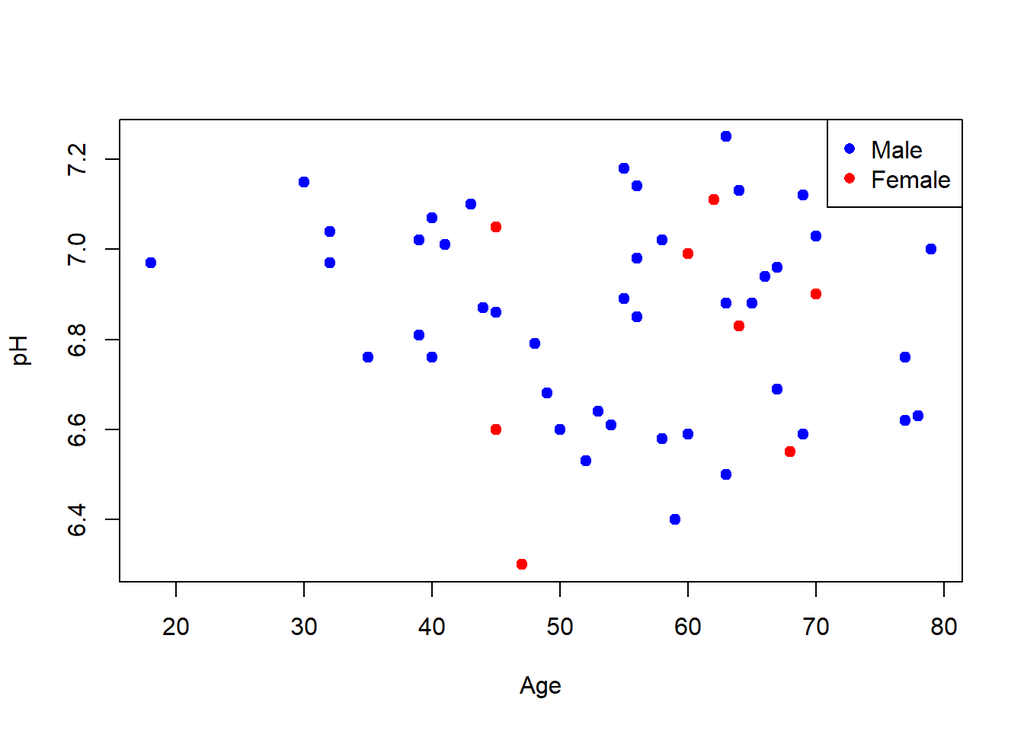

```r
plot(brain$Age, brain$pH, col = ifelse(brain$Sex == "M", "blue", "red"), pch = 19, xlab = "Age", ylab = "pH")
legend("topright", legend = c("Male", "Female"), pch = 16, col = c("blue", "red"))
```

The scatterplot shows that the male pH levels are more spread out than the female pH levels.

### b. Fit the regression of pH on Age and test whether there is a linear association between the two variables.

```r
summary(lm(pH ~ Age, data = brain))
```

```
##
## Call:
## lm(formula = pH ~ Age, data = brain)
##
## Residuals:
##      Min       1Q   Median       3Q      Max
## -0.56976 -0.21781  0.02032  0.16801  0.38649
##
## Coefficients:
##               Estimate Std. Error t value Pr(>|t|)
## (Intercept)  6.8881113  0.1321194   52.13   <2e-16 ***
## Age         -0.0003905  0.0022944   -0.17    0.866
## ---
## Signif. codes:  0 '***' 0.001 '**' 0.01 '*' 0.05 '.' 0.1 ' ' 1
##
## Residual standard error: 0.235 on 52 degrees of freedom
## Multiple R-squared:  0.0005566,  Adjusted R-squared:  -0.01866
## F-statistic: 0.02896 on 1 and 52 DF,  p-value: 0.8655
```

### c. Fit a model that produces parallel regression lines for the two levels of Sex. Write down the fitted prediction equation for each level of Sex.

```r
model_parallel <- lm(pH ~ Age + Sex, data = brain)
summary(model_parallel)
```

```
##
## Call:
## lm(formula = pH ~ Age + Sex, data = brain)
##
## Residuals:
##      Min       1Q   Median       3Q      Max
## -0.58126 -0.21456  0.02306  0.16722  0.38942
##
## Coefficients:
##               Estimate Std. Error t value Pr(>|t|)
## (Intercept)  6.9025758  0.1613711  42.775   <2e-16 ***
## Age         -0.0004535  0.0023499  -0.193    0.848
## SexM        -0.0134258  0.0843155  -0.159    0.874
## ---
## Signif. codes:  0 '***' 0.001 '**' 0.01 '*' 0.05 '.' 0.1 ' ' 1
##
## Residual standard error: 0.2372 on 51 degrees of freedom
## Multiple R-squared:  0.001053,   Adjusted R-squared:  -0.03812
## F-statistic: 0.02689 on 2 and 51 DF,  p-value: 0.9735
```

## Fluorescence Data Questions

### a. Fit a quadratic regression model for predicting ProteinProp from Calcium (if needed for the software you are using, create a new variable CalciumSq = Calcium x Calcium). Write down the fitted regression equation.

```r
fluorescence$CalciumSq <- fluorescence$Calcium^2
summary(lm(ProteinProp ~ Calcium + CalciumSq, data = fluorescence))
```

```
##
## Call:
## lm(formula = ProteinProp ~ Calcium + CalciumSq, data = fluorescence)
##
## Residuals:
##      Min       1Q   Median       3Q      Max
## -0.19782 -0.05926 -0.01287  0.06304  0.26462
##
## Coefficients:
##              Estimate Std. Error t value Pr(>|t|)
## (Intercept)  0.479926   0.317905   1.510  0.13769
## Calcium     -0.253189   0.084103  -3.010  0.00415 **
## CalciumSq   -0.027788   0.005425  -5.122 5.31e-06 ***
## ---
## Signif. codes:  0 '***' 0.001 '**' 0.01 '*' 0.05 '.' 0.1 ' ' 1
##
## Residual standard error: 0.09738 on 48 degrees of freedom
## Multiple R-squared:  0.8941, Adjusted R-squared:  0.8897
## F-statistic: 202.7 on 2 and 48 DF,  p-value: < 2.2e-16
```

### b. Add the quadratic curve to a scatterplot of ProteinProp versus Calcium.

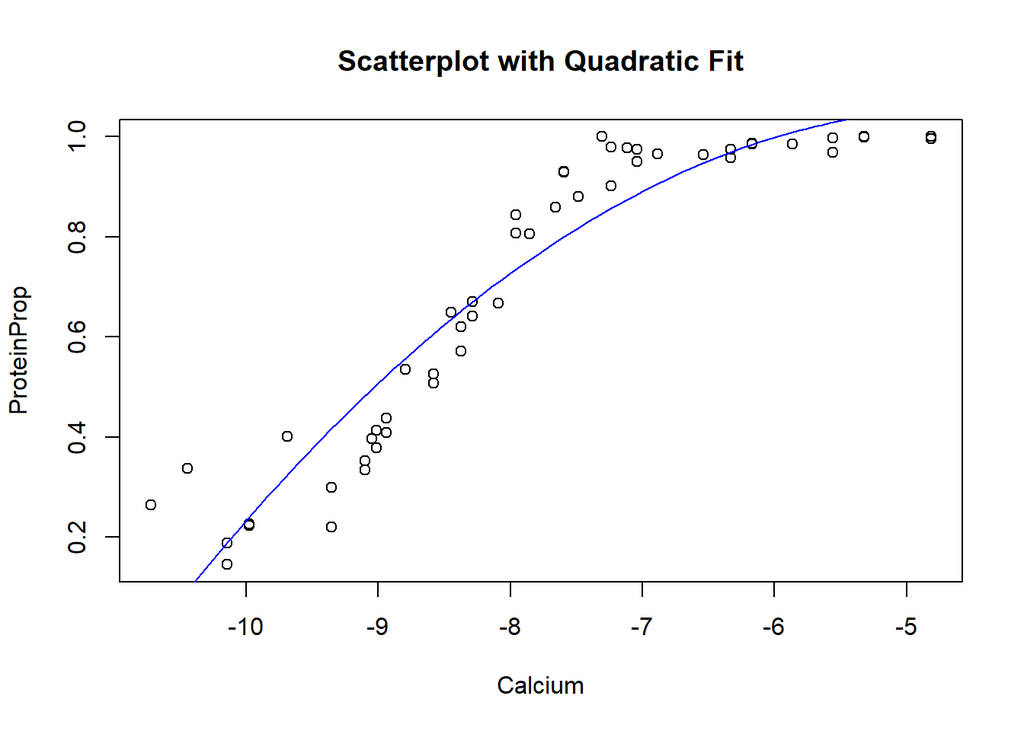

```r
model <- lm(ProteinProp ~ Calcium + CalciumSq, data = fluorescence)
plot(fluorescence$Calcium, fluorescence$ProteinProp, xlab = "Calcium", ylab = "ProteinProp", main = "Scatterplot with Quadratic Fit")
curve(coef(model)[1] + coef(model)[2] * x + coef(model)[3] * x^2, add = TRUE, col = "blue")
```

### c. Are the conditions for inference reasonably satisfied for this model?

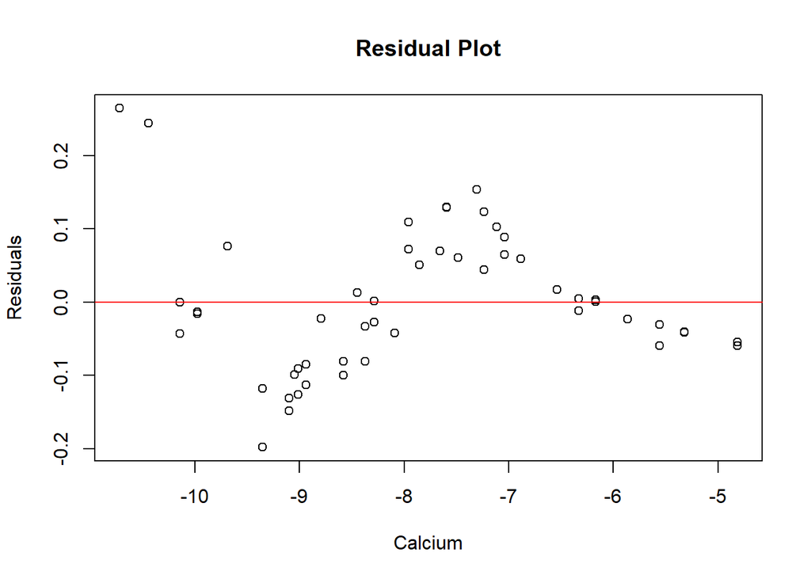

```r
model <- lm(ProteinProp ~ Calcium + CalciumSq, data = fluorescence)
plot(fluorescence$Calcium, resid(model), xlab = "Calcium", ylab = "Residuals", main = "Residual Plot")
abline(h = 0, col = "red")
```

Not really, there’s a clear pattern where the residuals start increasing and decreasing.

### d. Is the parameter for the quadratic term significantly different from zero? Justify your answer.

```r
summary(lm(ProteinProp ~ Calcium + CalciumSq, data = fluorescence))
```

```
##
## Call:
## lm(formula = ProteinProp ~ Calcium + CalciumSq, data = fluorescence)
##
## Residuals:
##      Min       1Q   Median       3Q      Max
## -0.19782 -0.05926 -0.01287  0.06304  0.26462
##
## Coefficients:
##              Estimate Std. Error t value Pr(>|t|)
## (Intercept)  0.479926   0.317905   1.510  0.13769
## Calcium     -0.253189   0.084103  -3.010  0.00415 **
## CalciumSq   -0.027788   0.005425  -5.122 5.31e-06 ***
## ---
## Signif. codes:  0 '***' 0.001 '**' 0.01 '*' 0.05 '.' 0.1 ' ' 1
##
## Residual standard error: 0.09738 on 48 degrees of freedom
## Multiple R-squared:  0.8941, Adjusted R-squared:  0.8897
## F-statistic: 202.7 on 2 and 48 DF,  p-value: < 2.2e-16
```

### e. Identify the coefficient of multiple determination and interpret this value.

```r
summary(lm(ProteinProp ~ Calcium + CalciumSq, data = fluorescence))$r.squared
```

```
## [1] 0.8941312
```